# Homework Assignment 3

Johnny JI

四月 19, 2022

##Load the data

```r
titanic<- read.csv("data/titanic.csv")
titanic$survived <- as.factor(titanic$survived)
titanic$pclass <- as.factor(titanic$pclass)
head(titanic)
```

|  | passenger_id | survived | pclass | name | sex | age | sib_sp | parch | ticket | fare | cabin | embarked |
| --- | --- | --- | --- | --- | --- | --- | --- | --- | --- | --- | --- | --- |
| 1 | 1 | No | 3 | Braund, Mr. Owen Harris | male | 22 | 1 | 0 | A/5 21171 | 7.250 | NA | S |
| 2 | 2 | Yes | 1 | Cumings, Mrs. John Bradley (Florence Briggs Thayer) | female | 38 | 1 | 0 | PC 17599 | 71.283 | C85 | C |
| 3 | 3 | Yes | 3 | Heikkinen, Miss. Laina | female | 26 | 0 | 0 | STON/O2. 3101282 | 7.925 | NA | S |
| 4 | 4 | Yes | 1 | Futrelle, Mrs. Jacques Heath (Lily May Peel) | female | 35 | 1 | 0 | 113803 | 53.100 | C123 | S |
| 5 | 5 | No | 3 | Allen, Mr. William Henry | male | 35 | 0 | 0 | 373450 | 8.050 | NA | S |
| 6 | 6 | No | 3 | Moran, Mr. James | male | NA | 0 | 0 | 330877 | 8.458 | NA | Q |

### Question 1

```r
titanic_split <- initial_split(titanic, prop = 0.80,strata = "survived")
titanic_train <- training(titanic_split)
titanic_test <- testing(titanic_split)
# checking the missing value
print(sapply(titanic_train, function(x) sum(is.na(x))))
```

```
## passenger_id     survived       pclass         name          sex          age
##            0            0            0            0            0          145
##       sib_sp        parch       ticket         fare        cabin     embarked
##            0            0            0            0          547            1
```

The goal to use stratified sampling stratified sampling is to make sure we have proper representation of the entire population being studied

### Question 2

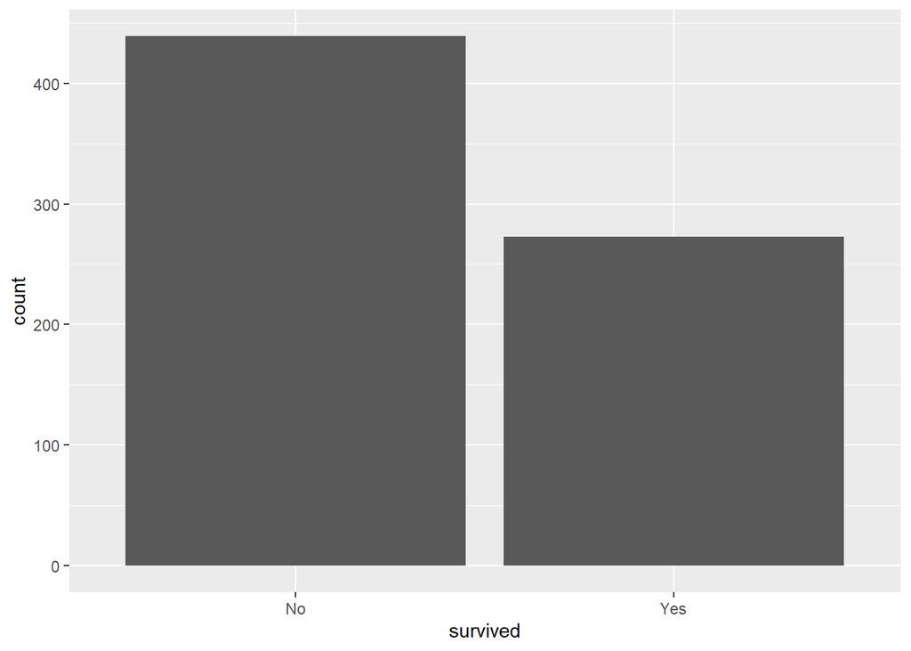

```r
titanic_train %>%
 ggplot(aes(x = survived)) +
 geom_bar()
```

We can see most people are not survived.

### Question 3

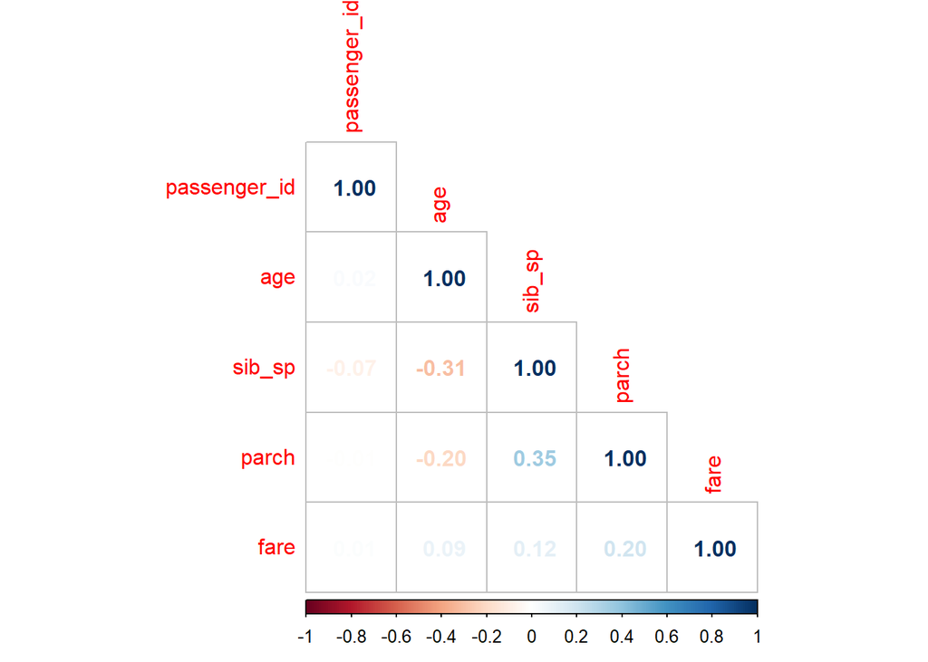

```r
#correlation matrix
titanic_train_cor = titanic_train[ , !(names(titanic_train) %in% c("cabin", "embarked"))] %>% copy()
titanic_train_cor = titanic_train_cor %>% drop_na()
corrplot(cor(titanic_train_cor[ , sapply(titanic_train_cor, is.numeric)]),
         method="number", type="lower")
```

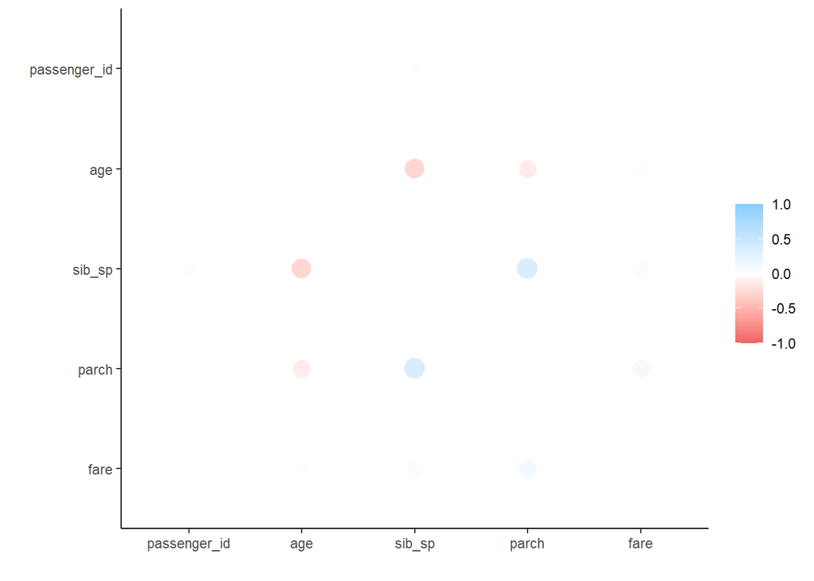

```r
#visualization matrix
cor_titanic <- select_if(titanic_train_cor,is.numeric) %>% correlate()
rplot(cor_titanic)
```

We can find that, negative correlation between the sib_sp and age, and positive correlation between the parch and sib_sp.

### Question 4

```r
titanic_recipe = recipe(survived ~ pclass + age+ sex +sib_sp + parch + fare, data=titanic_train) %>%
 step_impute_linear(age) %>%
 step_dummy(all_nominal_predictors()) %>%
 step_interact( ~ starts_with("sex"):fare+ age:fare)
```

### Question 5

```r
log_model = logistic_reg() %>%
  set_engine("glm") %>%
  set_mode("classification")
log_workflow = workflow() %>%
  add_model(log_model) %>%
  add_recipe(titanic_recipe)
log_fit<- fit(log_workflow, titanic_train)
```

### Question 6

```r
lda_model = discrim_linear() %>%
  set_engine("MASS") %>%
  set_mode("classification")
lda_workflow = workflow() %>%
  add_model(lda_model) %>%
  add_recipe(titanic_recipe)
lda_fit <- fit(lda_workflow, titanic_train)
```

### Question 7

```r
qda_model = discrim_quad() %>%
  set_engine("MASS") %>%
  set_mode("classification")
qda_workflow = workflow() %>%
  add_model(qda_model) %>%
  add_recipe(titanic_recipe)
qda_fit <- fit(qda_workflow, titanic_train)
```

### Question 8

```r
nb_mod <- naive_Bayes() %>%
 set_mode("classification") %>%
 set_engine("klaR") %>%
 set_args(usekernel = FALSE)
nb_workflow <- workflow() %>%
 add_model(nb_mod) %>%
 add_recipe(titanic_recipe)
nb_fit <- fit(nb_workflow, titanic_train)
```

### Question 9

```r
bound_train_data = bind_cols(predict(log_fit, titanic_train),
                             predict(lda_fit, titanic_train),
                             predict(qda_fit, titanic_train),
                             predict(nb_fit, titanic_train),
                             titanic_train$survived)
colnames(bound_train_data) = c("log Predict", "lda Predict", "qda Predict",
                               "NB Predict", "Truth")
```

```r
#The logistic model accuracy
print(augment(log_fit, new_data = titanic_train) %>%
 accuracy(truth = survived, estimate = .pred_class))
```

```
## # A tibble: 1 x 3
##   .metric  .estimator .estimate
##   <chr>    <chr>          <dbl>
## 1 accuracy binary         0.815
```

```r
#The linear discriminant analysis model accuracy
print(augment(lda_fit, new_data = titanic_train) %>%
 accuracy(truth = survived, estimate = .pred_class))
```

```
## # A tibble: 1 x 3
##   .metric  .estimator .estimate
##   <chr>    <chr>          <dbl>
## 1 accuracy binary         0.798
```

```r
#The quadratic discriminant analysis model accuracy
print( augment(qda_fit, new_data = titanic_train) %>%
 accuracy(truth = survived, estimate = .pred_class))
```

```
## # A tibble: 1 x 3
##   .metric  .estimator .estimate
##   <chr>    <chr>          <dbl>
## 1 accuracy binary         0.777
```

```r
#The native bayesian model accuracy
print( augment(nb_fit, new_data = titanic_train) %>%
 accuracy(truth = survived, estimate = .pred_class))
```

```
## # A tibble: 1 x 3
##   .metric  .estimator .estimate
##   <chr>    <chr>          <dbl>
## 1 accuracy binary         0.774
```

Therefore, logicstic model has the highest accuracy of 0.815

### Question 10

```r
bound_test_data = bind_cols(predict(log_fit, titanic_test),
                            titanic_test$survived)
colnames(bound_test_data) = c("log Predict", "True")
print(accuracy(bound_test_data,
               truth="True", estimate="log Predict")$.estimate)
```

```
## [1] 0.8101
```

The logistic regression model has about 81% accuracy on the test set.

```r
conf_mat(bound_test_data, truth="True", estimate="log Predict")
```

```
##           Truth
## Prediction No Yes
##        No  96  20
##        Yes 14  49
```

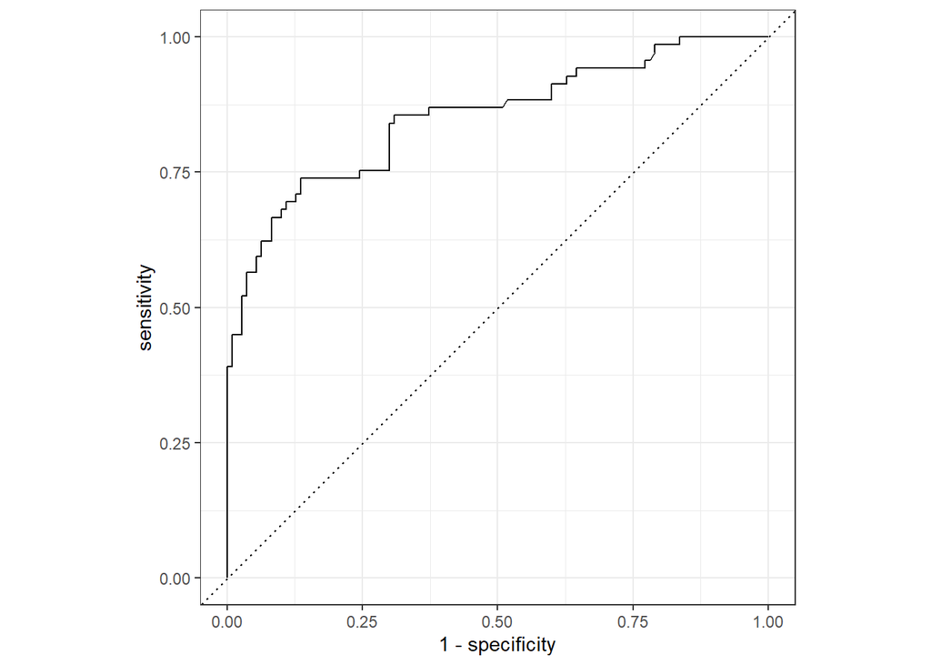

```r
roc = log_fit %>%
  predict(new_data=titanic_test, type="prob") %>%
  bind_cols(titanic_test) %>%
  roc_curve(survived, .pred_Yes, event_level="second")
autoplot(roc)
```

```r
auc = log_fit %>%
  predict(new_data=titanic_test, type="prob") %>%
  bind_cols(titanic_test) %>%
  roc_auc(survived, .pred_Yes, event_level="second")
print(auc$.estimate)
```

```
## [1] 0.8511
```

### Question 11

$e^z = \dfrac{p}{1-p}$

$1 + e^z = \dfrac{1-p}{1-p} + \dfrac{p}{1-p} = \dfrac{1}{1-p}$

$\dfrac{1}{1 + e^z} = 1 - p$

Thus we get that

$p = 1 - \dfrac{1}{1 + e^z} = \dfrac{e^z}{1 + e^z}$

### Question 12

When increase by 2, we get that

$z= \beta_0 +\beta_1(x_1 +2)$

which we know that

$\beta_0 +\beta_1x_1 =log(\dfrac {p(z)}{1-p(z)})=\dfrac{e^{\beta_0 + \beta1x1}}{1+e^{\beta_0 + \beta1x1}}$

Then

$logstic(z)=\dfrac{e^{\beta_0 + \beta1x1} e^{2\beta1}}{1+e^{\beta_0 + \beta1x1} e^{2\beta1}}$

If$\beta_1$ is negative then increasing$x_1$ will be associated with decreasing $p$.$p$ approach$0$ as$x_1$ approaches$\infty$ , and$p$ approach$1$ as $x_1$ approaches$-\infty$ .